# Principal Component Analysis

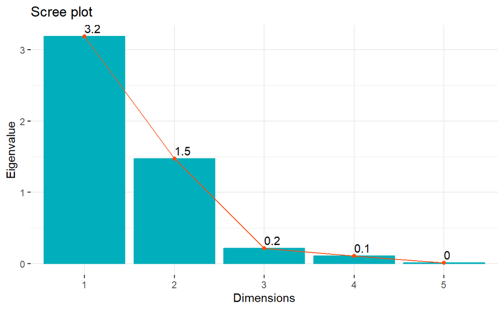

```r
# 스크리 그래프 Ver.2
fviz_screeplot(student.cor.prcomp,
               addlabels = TRUE,                       # 막대 높이 표시 여부
               # geom = "line",                        # 그래프 유형(bar / line)
               choice = "eigenvalue",                  # y축 (variance / eigenvalue)
               linecolor = "#FC4E07",                  # 선 색깔
               barcolor = "#00AFBB",                   # 막대의 윤곽선 색깔
               barfill = "#00AFBB")                    # 막대의 색깔
```

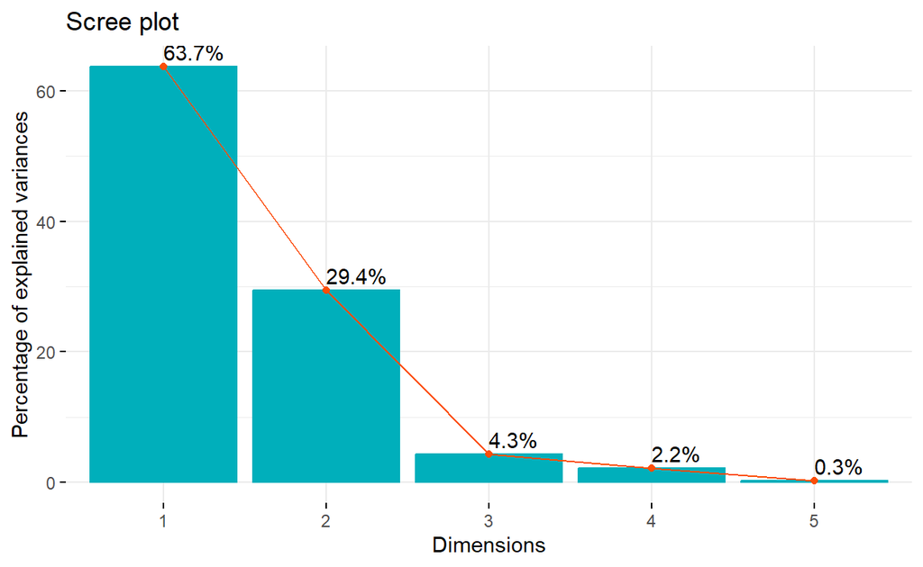

```r
fviz_screeplot(student.cor.prcomp,
               addlabels = TRUE,                       # 막대 높이 표시 여부
               choice = "variance",                    # y축(variance / eigenvalue)
               linecolor = "#FC4E07",                  # 선 색깔
               barcolor = "#00AFBB",                   # 막대의 윤곽선 색깔
               barfill = "#00AFBB")                    # 막대의 색깔
```

`Result!` 스크리 그래프를 보면 첫 번째 주성분과 두 번째 주성분의 분산(고유값)이 크며 가파른 경사를 형성한다. 그러므로, 2개의 주성분 개수를 고려할 수 있다.

# **예제 3**

- Package `"mclust"`에서 제공하는 데이터 `banknote`는 100개의 진품과 100개의 위조 옛날 스위스 1000프랑 지폐에 대해 측정된 6개의 변수값을 제공한다.
  1. `Status` : 지폐의 상태
     - genuine : 진품
     - counterfeit : 위조
  2. `Length` : 지폐의 길이
  3. `Left` : 왼쪽 가장자리 너비
  4. `Right` : 오른쪽 가장자리 너비
  5. `Bottom` : 하단 여백 너비
  6. `Top` : 상단 여백 너비
  7. `Diagonal` : 대각선 길이

## **1. 데이터 불러오기**

```r
# 데이터 불러오기
data(banknote, package = "mclust")

swissTib <- as_tibble(banknote)
swissTib
```

```
# A tibble: 200 × 7
   Status  Length  Left Right Bottom   Top Diagonal
   <fct>    <dbl> <dbl> <dbl>  <dbl> <dbl>    <dbl>
 1 genuine   215.  131   131.    9     9.7     141
 2 genuine   215.  130.  130.    8.1   9.5     142.
 3 genuine   215.  130.  130.    8.7   9.6     142.
 4 genuine   215.  130.  130.    7.5  10.4     142
 5 genuine   215   130.  130.   10.4   7.7     142.
 6 genuine   216.  131.  130.    9    10.1     141.
 7 genuine   216.  130.  130.    7.9   9.6     142.
 8 genuine   214.  130.  129.    7.2  10.7     142.
 9 genuine   215.  129.  130.    8.2  11       142.
10 genuine   215.  130.  130.    9.2  10       141.
# ℹ 190 more rows
```

## **2. 데이터 탐색**

### **2-1. 기술통계량**

```r
describe(swissTib[,-1])
```

```
         vars   n   mean   sd median trimmed  mad   min   max range
Length      1 200 214.90 0.38 214.90  214.89 0.30 213.8 216.3   2.5
Left        2 200 130.12 0.36 130.20  130.13 0.44 129.0 131.0   2.0
Right       3 200 129.96 0.40 130.00  129.96 0.44 129.0 131.1   2.1
Bottom      4 200   9.42 1.44   9.10    9.35 1.63   7.2  12.7   5.5
Top         5 200  10.65 0.80  10.60   10.66 0.89   7.7  12.3   4.6
Diagonal    6 200 140.48 1.15 140.45  140.52 1.56 137.8 142.4   4.6
          skew kurtosis   se
Length    0.19     0.71 0.03
Left     -0.19    -0.59 0.03
Right     0.04    -0.19 0.03
Bottom    0.37    -1.05 0.10
Top      -0.23     0.15 0.06
Diagonal -0.19    -1.15 0.08
```

`Result!` 변수 `Bottom`의 표준편차는 다른 변수들에 비해 상대적으로 큰 반면, 변수 `Left`의 표준편차는 다른 변수들에 비해 상대적으로 작다.

### **2-2. 상관행렬**

```r
cor(swissTib[,-1])
```

```
              Length       Left      Right     Bottom         Top
Length    1.00000000  0.2312926  0.1517628 -0.1898009 -0.06132141
Left      0.23129257  1.0000000  0.7432628  0.4137810  0.36234960
Right     0.15176280  0.7432628  1.0000000  0.4867577  0.40067021
Bottom   -0.18980092  0.4137810  0.4867577  1.0000000  0.14185134
Top      -0.06132141  0.3623496  0.4006702  0.1418513  1.00000000
Diagonal  0.19430146 -0.5032290 -0.5164755 -0.6229827 -0.59404464
           Diagonal
Length    0.1943015
Left     -0.5032290
Right    -0.5164755
Bottom   -0.6229827
Top      -0.5940446
Diagonal  1.0000000
```

`Result!` 변수 `Left`와 `Right` 사이의 상관계수는 0.74로 가장 강한 양의 상관성을 보인다. 게다가, 변수 `Bottom`과 `Diagonal` 사이의 상관계수는 -0.62로 강한 음의 상관성을 보인다.

### **2-3. 산점도행렬**

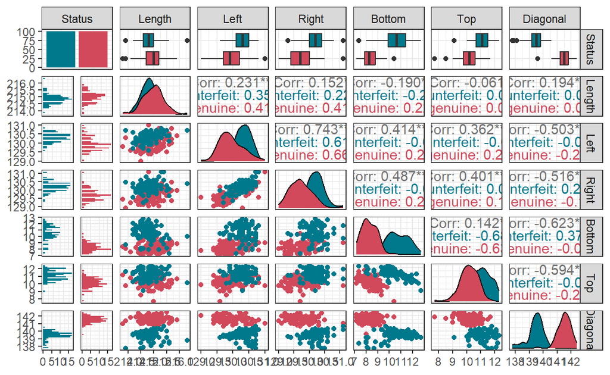

```r
ggpairs(swissTib,
  mapping = aes(col = Status), alpha = 0.8) +               # 변수 Status의 범주에 따라 색깔을 다르게 표현
  scale_colour_manual(values = c("#00798c", "#d1495b")) +   # 특정 색깔 지정
  scale_fill_manual(values = c("#00798c", "#d1495b")) +     # 특정 색깔 지정
  theme_bw()
```

## **3. 공분산행렬을 이용한 주성분분석**

```r
swissTib.prcomp <- select(swissTib, -Status) %>%
  prcomp()
swissTib.prcomp
```

```
Standard deviations (1, .., p=6):
[1] 1.7321388 0.9672748 0.4933697 0.4412015 0.2919107 0.1884534

Rotation (n x k) = (6 x 6):
                 PC1         PC2       PC3        PC4         PC5
Length    0.04377427 -0.01070966 0.3263165 -0.5616918 -0.75257278
Left     -0.11216159 -0.07144697 0.2589614 -0.4554588  0.34680082
Right    -0.13919062 -0.06628208 0.3447327 -0.4153296  0.53465173
Bottom   -0.76830499  0.56307225 0.2180222  0.1861082 -0.09996771
Top      -0.20176610 -0.65928988 0.5566857  0.4506985 -0.10190229
Diagonal  0.57890193  0.48854255 0.5917628  0.2584483  0.08445895
                 PC6
Length    0.09809807
Left     -0.76651197
Right     0.63169678
Bottom   -0.02221711
Top      -0.03485874
Diagonal -0.04567946
```

`Caution!` 주성분분석은 함수 `prcomp()`를 통해 수행할 수 있다. 자세한 옵션은 `?prcomp`를 통해 확인하거나 [여기](https://www.rdocumentation.org/packages/stats/versions/3.6.2/topics/prcomp)를 참고한다.  
`Result!` 함수 `prcomp()`는 5개의 결과를 리스트로 반환한다.

1. `sdev` : 데이터셋을 주성분에 투영했을 때의 표준편차인 주성분의 표준편차(= 공분산행렬의 고유값의 제곱근)
   - 출력 결과의 “Standard deviations”와 동일
2. `rotation` : 주축의 계수(= 공분산행렬의 단위 고유벡터)
   - 출력 결과의 “Rotation”과 동일
3. `center` : 변수의 평균
4. `scale` : 표준편차로 나누어 주는 작업 진행 여부
5. `x` : 주성분 점수

```r
swissTib.prcomp$sdev                # 주성분의 표준편차
```

```
[1] 1.7321388 0.9672748 0.4933697 0.4412015 0.2919107 0.1884534
```

```r
swissTib.prcomp$sdev^2              # 주성분의 분산 = 주성분에 의해 설명되는 분산의 양 = 공분산행렬의 고유값
```

```
[1] 3.00030487 0.93562052 0.24341371 0.19465874 0.08521185 0.03551468
```

`Caution!` 주성분의 분산은 함수 `eigen(cov(swissTib[,-1]))`를 통해 얻어진 공분산행렬의 고유값과 동일하며, 공분산행렬의 대각성분 합이 주성분 분산의 합(공분산행렬의 고유값의 합)과 같음을 알 수 있다.

```r
swissTib.prcomp$rotation            # 주축의 계수
```

```
                 PC1         PC2       PC3        PC4         PC5
Length    0.04377427 -0.01070966 0.3263165 -0.5616918 -0.75257278
Left     -0.11216159 -0.07144697 0.2589614 -0.4554588  0.34680082
Right    -0.13919062 -0.06628208 0.3447327 -0.4153296  0.53465173
Bottom   -0.76830499  0.56307225 0.2180222  0.1861082 -0.09996771
Top      -0.20176610 -0.65928988 0.5566857  0.4506985 -0.10190229
Diagonal  0.57890193  0.48854255 0.5917628  0.2584483  0.08445895
                 PC6
Length    0.09809807
Left     -0.76651197
Right     0.63169678
Bottom   -0.02221711
Top      -0.03485874
Diagonal -0.04567946
```

`Caution!` 주축의 계수는 함수 `eigen(cov(swissTib[,-1]))`를 통해 얻어진 공분산행렬의 단위 고유벡터와 동일하다.  
`Result!` 첫 번째 주성분은 $Y_1=0.044C_{\text{Length}}-0.112C_{\text{Left}}-0.139C_{\text{Right}}-768C_{\text{Bottom}}-0.202C_{\text{Top}}+0.579C_{\text{Diagonal}}$이며, 두 번째 주성분은 $Y_2=-0.011C_{\text{Length}}-0.071C_{\text{Left}}-0.066C_{\text{Right}}+0.563C_{\text{Bottom}}-0.659C_{\text{Top}}+0.489C_{\text{Diagonal}}$가 된다. 여기서 확률변수 $C_{i}$는 $X_i-\mu_i$이며, $\mu_i$는 $X_i$의 평균을 의미한다. 또한, 변수 `Left`의 확률변수를 $X_{\text{Left}}$로 나타내며, 다른 변수들도 동일한 방식으로 나타낸다.

```r
# 요약
summary(swissTib.prcomp)
```

```
Importance of components:
                          PC1    PC2     PC3     PC4     PC5    PC6
Standard deviation     1.7321 0.9673 0.49337 0.44120 0.29191 0.1885
Proportion of Variance 0.6675 0.2082 0.05416 0.04331 0.01896 0.0079
Cumulative Proportion  0.6675 0.8757 0.92983 0.97314 0.99210 1.0000
```

`Result!` 처음 2개의 고유값은 3.000(= $1.7321^2$), 0.936(= $0.9673^2$)로서 각각 전체 변동의 66.8%(= 3.000/4.4947)와 20.8%(= 0.936/4.4947)를 차지한다. 따라서, 처음 2개의 주성분에 의해 데이터 변동의 약 87.6%가 설명될 수 있음을 알 수 있다. 이는 2개의 주성분만으로 데이터 변동을 충분히 설명할 수 있음을 의미한다. 만약 처음 2개의 주성분을 새로운 변수로 고려할 경우, 이는 원래 여섯 개의 예측변수들이 가지고 있는 정보를 2차원으로 축소한다는 의미이다.

```r
# 변수 적재 Ver.1
1:6 %>%                                                # 첫 번째 변수부터 여섯 번째 변수에 function을 적용
  map_df(function(x) swissTib.prcomp$rotation[,x]*swissTib.prcomp$sdev[x])
```

```
# A tibble: 6 × 6
   Length    Left   Right   Bottom      Top Diagonal
    <dbl>   <dbl>   <dbl>    <dbl>    <dbl>    <dbl>
1  0.0758 -0.194  -0.241  -1.33    -0.349    1.00
2 -0.0104 -0.0691 -0.0641  0.545   -0.638    0.473
3  0.161   0.128   0.170   0.108    0.275    0.292
4 -0.248  -0.201  -0.183   0.0821   0.199    0.114
5 -0.220   0.101   0.156  -0.0292  -0.0297   0.0247
6  0.0185 -0.144   0.119  -0.00419 -0.00657 -0.00861
```

`Caution!` 주성분의 변수 적재(Variable Loading)는 단위 고유벡터(= 주축의 계수)와 고유값의 제곱근(= 주성분의 표준편차)을 곱함으로써 계산될 수 있다. 변수 적재를 계산하기 위해 함수 `map_df()`를 이용한다.  
`Result!` 변수 적재는 각 변수가 특정 주성분에 얼마나 기여하는지를 설명한다. 결과값의 부호는 양/음의 상관관계를 나타내며, 값의 절대값이 클수록 주성분과 변수는 강한 관계를 가지고 있다. 출력 결과는 주성분과 변수 사이의 공분산처럼 해석할 수 있다. 예를 들어, 변수 `Bottom`은 첫 번째 주성분과 음의 상관성(-1.33)을 가지고 있으며, 변수 `Diagonal`은 첫 번째 주성분과 양의 상관성(1.00)을 가지고 있다.

```r
# 변수 적재 Ver.2
pcaDat <- get_pca(swissTib.prcomp)                     # 주성분 결과에서 변수에 대한 정보(좌표, 제곱 코사인, 기여) 추출
round(pcaDat$coord,3)                                  # 변수 적재
```

```
          Dim.1  Dim.2 Dim.3  Dim.4  Dim.5  Dim.6
Length    0.076 -0.010 0.161 -0.248 -0.220  0.018
Left     -0.194 -0.069 0.128 -0.201  0.101 -0.144
Right    -0.241 -0.064 0.170 -0.183  0.156  0.119
Bottom   -1.331  0.545 0.108  0.082 -0.029 -0.004
Top      -0.349 -0.638 0.275  0.199 -0.030 -0.007
Diagonal  1.003  0.473 0.292  0.114  0.025 -0.009
```

`Caution!` 변수 적재는 package `"factoextra"`에서 제공하는 함수 `get_pca()`를 이용하여 계산할 수 있다.

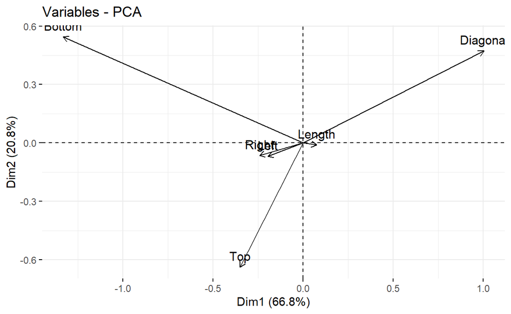

```r
# 변수 적재 그래프
fviz_pca_var(swissTib.prcomp)
```

`Result!` 그래프의 x축과 y축은 각각 첫 번째 주성분과 두 번째 주성분에 대한 변수 적재값을 의미하며, 특정 주축을 기준으로 화살표의 길이가 길수록 해당 변수와 해당 주성분은 강한 상관성을 가진다.

```r
# 주성분 점수
swissTib.score <- swissTib.prcomp$x
swissTib.score
```

```
               PC1          PC2          PC3           PC4
  [1,]  0.54964810  0.506373006  0.275864575 -1.1937281200
  [2,]  2.01862924  0.661263637 -0.501997459  0.0154448639
  [3,]  1.83567546  1.175307339  0.045629151  0.1890654554
  [4,]  2.49436724 -0.118891563  0.076525211  0.3161376917
  [5,]  0.70132282  3.194766676 -0.838773875 -0.5210495315
  [6,]  0.84584597  0.482494017  0.770296914 -1.0753024458
  [7,]  2.15605260  0.438516644 -0.307217041 -0.4169825947
  [8,]  2.54441845 -0.595292540 -0.261088782  0.6981655399
  [9,]  1.80171073 -0.155434257  0.493392385  0.7299232166
 [10,]  0.35794585  0.366247704  0.008309448 -0.7179691519
 [11,]  1.65490951 -0.950213178  1.354817025  0.0344015973
 [12,]  2.47187462  0.036578902  0.340253464  0.3727030793
 [13,]  1.65312961 -0.533379672  0.446734754 -0.3098899888
 [14,]  2.04785612 -0.488042059  0.222785259  0.5158103065
```

[output cut: 387 more lines]

`Caution!` 주성분 점수는 각 case의 관측값을 주성분에 대입함으로써 얻을 수 있으며, 고차원의 원본 데이터셋 대신 차원이 축소된 데이터셋으로 유용하게 사용될 수 있다. 함수 `prcomp()`를 이용한 결과 `swissTib.prcomp`에는 주성분 점수가 포함되어 있다.
`Result!` 첫 번째 주성분과 두 번째 주성분에 의해 얻어지는 $i$번째 case의 주성분 점수는 다음의 식을 이용하여 얻을 수 있다.
$$\begin{align}
\begin{cases}
y_{i1}=0.044c_{i1}-0.112c_{i2}-0.139c_{i3}-0.768c_{i4}-0.202c_{i5}+0.579c_{i6},\\
y_{i2}=-0.011c_{i1}-0.071c_{i2}-0.066c_{i3}+0.563c_{i4}-0.659c_{i5}+0.489c_{i6},
\end{cases}
\end{align}$$
여기서 $c_{ij}=x_{ij}-\bar{x}_{j}$는 $i$번째 case의 $j$번째 변수 관찰값 $x_{ij}$에서 $j$번째 변수의 평균값 $\bar{x}_j$을 뺀 것을 의미한다.

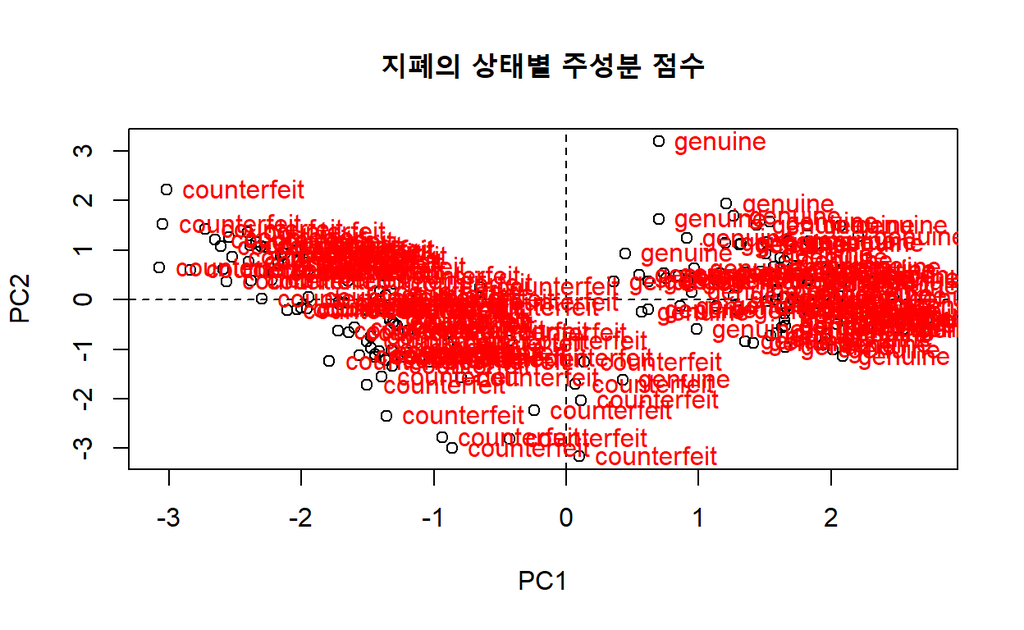

```r
# 지폐의 상태에 따른 주성분 점수 그래프 Ver.1
plot(swissTib.score[,1:2],                             # 첫 번째와 두 번째 주성분 점수
     main = "지폐의 상태별 주성분 점수")
abline(v = 0, h = 0, lty = 2)
text(swissTib.score[,1:2],  labels = swissTib$Status, pos = 4, col = "red")
```

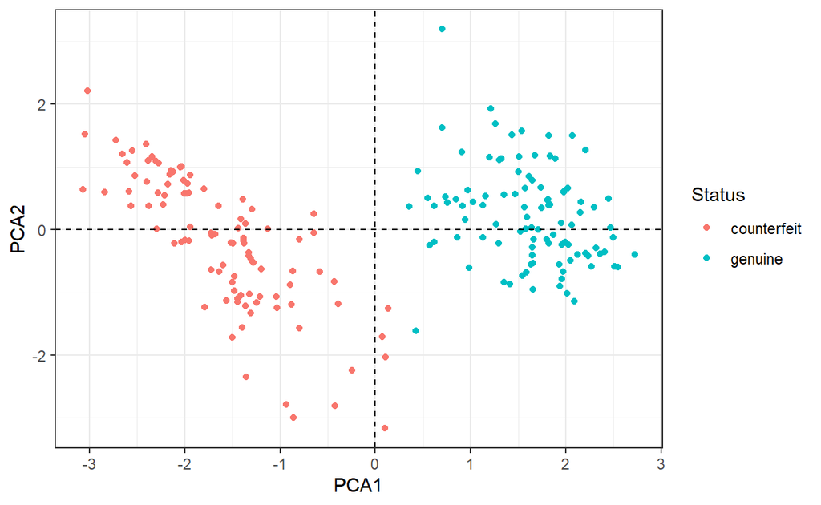

```r
# 지폐의 상태에 따른 주성분 점수 그래프 Ver.2
swissTibPca <- swissTib %>%
  mutate(PCA1 = swissTib.score[, 1], PCA2 = swissTib.score[, 2])
ggplot(swissTibPca, aes(PCA1, PCA2,
                        col = Status)) +               # 변수 Status의 범주에 따라 색깔을 다르게 표현
  geom_point() +
  geom_hline(yintercept=0, linetype='dashed', color='black') +
  geom_vline(xintercept=0, linetype='dashed', color='black') +
  theme_bw()
```

`Result!` 그래프의 수직선을 중심으로 오른쪽에 위치하는 점들은 첫 번째 주성분 점수가 높다는 것을 의미하고 왼쪽에 위치하는 점들은 첫 번째 주성분 점수가 낮다는 것을 의미한다. 오른쪽에 위치하는 점들은 대부분 “진품”(genuine)이므로, 전반적으로 진품인 지폐가 위조 지폐보다 첫 번째 주성분 점수가 높다고 해석할 수 있다. 마찬가지로 수평선을 중심으로 위쪽에 위치하는 점들은 두 번째 주성분 점수가 높다는 것을 의미하고 아래쪽에 위치하는 점들은 두 번째 주성분 점수가 낮다는 것을 의미한다.

```r
# 주성분 점수 예측
predict(swissTib.prcomp, newdata = tail(swissTib[,-1], 2))
```

```
           PC1         PC2        PC3        PC4       PC5        PC6
[1,] -2.298487  0.01691873  0.4299815 -0.2043539 0.4734083 0.06091866
[2,] -1.277440 -0.52513666 -0.1506376  0.7592775 0.1020990 0.06898550
```

`Caution!` 함수 `predict()`를 이용하여 새로운 case에 대한 주성분 점수를 예측할 수 있다. 여기서는 설명의 편의상 마지막 2개의 case를 새로운 자료로 취급하여 예측을 수행하였다.

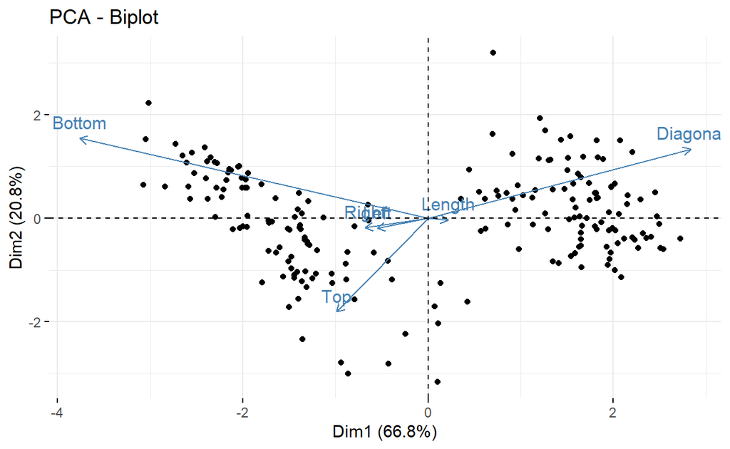

```r
# Biplot
fviz_pca_biplot(swissTib.prcomp, label = "var")
```

`Caution!` 주성분 점수와 변수 적재를 하나의 그래프에 함께 표현한 것을 행렬도(Biplot)라고 한다. 위 Biplot에서는 주성분 점수를 점으로 표현하고, 변수 적재를 화살표로 표현한다. Biplot는 다음을 기준으로 해석할 수 있다.  
1. 점은 각 case(데이터셋에서 하나의 행)에 대한 주성분 점수를 나타낸다.  
2. 화살표는 변수 적재값을 의미하며, 정확한 변수 적재값은 알 수 없다.  
3. 화살표의 길이는 상관성의 정도를 표현한다. 즉, 주축을 기준으로 화살표의 길이가 길수록 변수와 해당 주성분은 강한 상관성을 가진다.  
4. 화살표와 주축이 평행에 가까울수록 해당 변수는 해당 주성분에만 큰 영향을 미친다.  
5. 화살표들 간의 각도가 작을수록 해당 변수들은 강한 양의 상관관계를 나타내며, 180도는 강한 음의 상관관계를 나타낸다. 또한, 직각은 상관성이 없음을 의미한다.  
Biplot을 통해서 군집성, 변수들의 상관구조 등을 시각적으로 파악할 수 있다.  
`Result!` Biplot의 x축과 y축은 각각 첫 번째와 두 번째 주성분 점수를 의미한다. 변수 `Bottom`과 `Diagonal`은 첫 번째 주축(x축, 수평 점선)을 기준으로 화살표의 길이가 길며 이는 두 변수가 첫 번째 주성분과 강한 상관성을 가진다고 할 수 있다. 또한, 변수 `Right`와 `Left`의 화살표들 간의 각도가 작기 때문에(즉, 서로 가까이 위치해있기 때문에) 강한 양의 상관관계를 가지며, 변수 `Right`와 `Diagonal`은 화살표들 간의 각도가 180도를 이루므로 강한 음의 상관관계를 가진다.

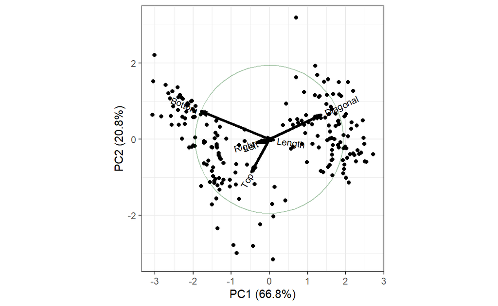

```r
# ggbiplot을 이용한 Biplot
ggbiplot(swissTib.prcomp,                              # 함수 prcomp에 의한 객체
         obs.scale = 1,                                # 관찰값에 적용할 스케일
         var.scale = 1,                                # 변수에 적용할 스케일
         circle = TRUE) +
  theme_bw()
```

`Caution!` Package `"ggbiplot"`에서 제공하는 함수 `ggbiplot()`를 이용하여 Biplot을 만들 수 있으며, 함수에 대한 자세한 옵션은 [여기](https://www.rdocumentation.org/packages/ggbiplot/versions/0.55/topics/ggbiplot)를 참고한다.

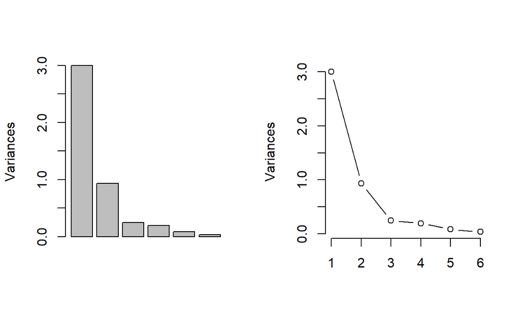

```r
# 스크리 그래프 Ver.1 (y축 : 고유값)
par(mfrow = c(1, 2))
screeplot(swissTib.prcomp, type = "b", main = "")      # 막대그래프
screeplot(swissTib.prcomp, type = "l", main = "")      # 선 그래프
```

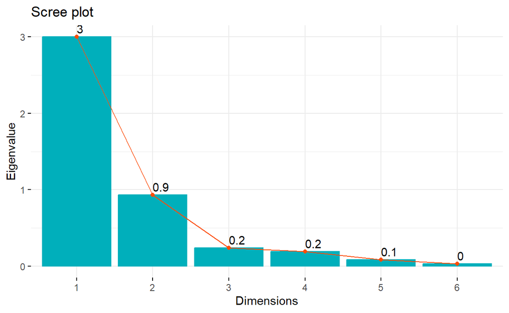

```r
# 스크리 그래프 Ver.2
fviz_screeplot(swissTib.prcomp,
               addlabels = TRUE,                       # 막대 높이 표시 여부
               # geom = "line",                        # 그래프 유형(bar / line)
               choice = "eigenvalue",                  # y축 (variance / eigenvalue)
               linecolor = "#FC4E07",                  # 선 색깔
               barcolor = "#00AFBB",                   # 막대의 윤곽선 색깔
               barfill = "#00AFBB")                    # 막대의 색깔
```

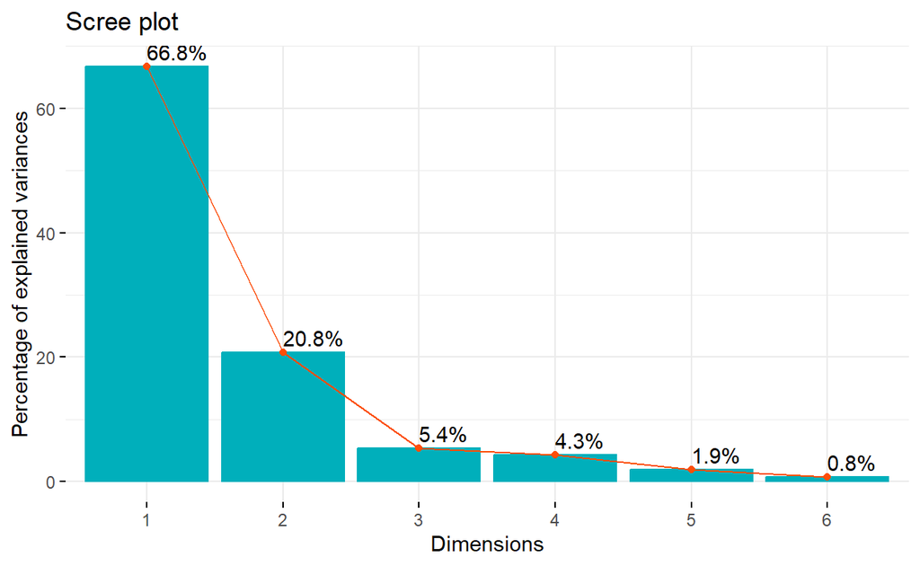

```r
fviz_screeplot(swissTib.prcomp,
               addlabels = TRUE,                       # 막대 높이 표시 여부
               choice = "variance",                    # y축(variance / eigenvalue)
               linecolor = "#FC4E07",                  # 선 색깔
               barcolor = "#00AFBB",                   # 막대의 윤곽선 색깔
               barfill = "#00AFBB")                    # 막대의 색깔
```

`Result!` 스크리 그래프를 보면 첫 번째 주성분과 두 번째 주성분의 분산(고유값)이 크며 가파른 경사를 형성한다. 그러므로, 2개의 주성분 개수를 고려할 수 있다.

## **4. 상관행렬을 이용한 주성분분석**

```r
swissTib.cor.prcomp <- select(swissTib, -Status) %>%
  prcomp(center = TRUE, scale = TRUE)
swissTib.cor.prcomp
```

```
Standard deviations (1, .., p=6):
[1] 1.7162629 1.1305237 0.9322192 0.6706480 0.5183405 0.4346031

Rotation (n x k) = (6 x 6):
                  PC1         PC2         PC3        PC4        PC5
Length    0.006987029 -0.81549497  0.01768066  0.5746173 -0.0587961
Left     -0.467758161 -0.34196711 -0.10338286 -0.3949225  0.6394961
Right    -0.486678705 -0.25245860 -0.12347472 -0.4302783 -0.6140972
Bottom   -0.406758327  0.26622878 -0.58353831  0.4036735 -0.2154756
Top      -0.367891118  0.09148667  0.78757147  0.1102267 -0.2198494
Diagonal  0.493458317 -0.27394074 -0.11387536 -0.3919305 -0.3401601
                 PC6
Length    0.03105698
Left     -0.29774768
Right     0.34915294
Bottom   -0.46235361
Top      -0.41896754
Diagonal -0.63179849
```

`Caution!` 상관행렬에 기초하여 주성분분석을 수행한다는 것은 표준화된 변수를 이용하여 주성분분석을 수행한다는 것을 의미한다. 함수 `prcomp()`의 옵션 `center = TRUE`와 `scale = TRUE`를 지정하여 변수를 표준화한 후, 상관행렬에 기초한 주성분분석을 수행할 수 있다.  
`Result!` 상관행렬을 이용한 주성분분석 결과는 위에서 공분산행렬에 기초하여 수행한 주성분분석 결과와는 다른 것을 확인할 수 있다.

```r
swissTib.cor.prcomp$sdev        # 주성분의 표준편차
```

```
[1] 1.7162629 1.1305237 0.9322192 0.6706480 0.5183405 0.4346031
```

```r
swissTib.cor.prcomp$sdev^2      # 주성분의 분산 = 주성분에 의해 설명되는 분산의 양 = 상관행렬의 고유값
```

```
[1] 2.9455582 1.2780838 0.8690326 0.4497687 0.2686769 0.1888799
```

`Caution!` 주성분의 분산은 함수 `eigen(cor(swissTib[,-1]))`를 통해 얻어진 상관행렬의 고유값과 동일하며, 상관행렬의 대각성분 합이 주성분 분산의 합(상관행렬의 고유값의 합)인 변수 개수 “6”과 같음을 알 수 있다.

```r
swissTib.cor.prcomp$rotation    # 주축의 계수
```

```
                  PC1         PC2         PC3        PC4        PC5
Length    0.006987029 -0.81549497  0.01768066  0.5746173 -0.0587961
Left     -0.467758161 -0.34196711 -0.10338286 -0.3949225  0.6394961
Right    -0.486678705 -0.25245860 -0.12347472 -0.4302783 -0.6140972
Bottom   -0.406758327  0.26622878 -0.58353831  0.4036735 -0.2154756
Top      -0.367891118  0.09148667  0.78757147  0.1102267 -0.2198494
Diagonal  0.493458317 -0.27394074 -0.11387536 -0.3919305 -0.3401601
                 PC6
Length    0.03105698
Left     -0.29774768
Right     0.34915294
Bottom   -0.46235361
Top      -0.41896754
Diagonal -0.63179849
```

`Caution!` 주축의 계수는 함수 `eigen(cor(swissTib[,-1]))`를 통해 얻어진 상관행렬의 단위 고유벡터와 동일하다.  
`Result!` 첫 번째 주성분은 $Y_1=0.007Z_{\text{Length}}-0.468Z_{\text{Left}}-0.487Z_{\text{Right}}-0.407Z_{\text{Bottom}}-0.368Z_{\text{Top}}+0.493Z_{\text{Diagonal}}$이며, 두 번째 주성분은 $Y_2=-0.815Z_{\text{Length}}-0.342Z_{\text{Left}}-0.252Z_{\text{Right}}+0.266Z_{\text{Bottom}}+0.091Z_{\text{Top}}-0.274Z_{\text{Diagonal}}$가 된다. 여기서 확률변수 $Z_{i}$는 $(X_i-\mu_i)/\sigma_{i}$이며, $\mu_i$와 $\sigma_{i}$는 각각 $X_i$의 평균과 표준편차를 의미한다. 또한, 변수 `Left`의 확률변수를 $X_{\text{Left}}$로 나타내며, 다른 변수들도 동일한 방식으로 나타낸다.

```r
# 요약
summary(swissTib.cor.prcomp)
```

```
Importance of components:
                          PC1    PC2    PC3     PC4     PC5     PC6
Standard deviation     1.7163 1.1305 0.9322 0.67065 0.51834 0.43460
Proportion of Variance 0.4909 0.2130 0.1448 0.07496 0.04478 0.03148
Cumulative Proportion  0.4909 0.7039 0.8488 0.92374 0.96852 1.00000
```

`Result!` 처음 3개의 고유값은 2.9456(= $1.7163^2$), 1.2781(= $1.1305^2$), 0.8690(= $0.9322^2$)로서 각각 전체 변동의 49.1%(= 2.9456/6), 21.3%(= 1.2781/6) 그리고 14.5%(= 0.8690/6)를 차지한다. 따라서, 처음 3개의 주성분에 의해 데이터 변동의 약 84.9%가 설명될 수 있음을 알 수 있다. 이는 3개의 주성분만으로 데이터 변동을 충분히 설명할 수 있음을 의미한다. 만약 처음 3개의 주성분을 새로운 변수로 고려할 경우, 이는 원래 여섯 개의 예측변수들이 가지고 있는 정보를 3차원으로 축소한다는 의미를 가진다.

```r
# 변수 적재 Ver.1
1:6 %>%                                                # 첫 번째 변수부터 여섯 번째 변수에 function을 적용
  map_df(function(x) swissTib.cor.prcomp$rotation[,x]*swissTib.cor.prcomp$sdev[x])
```

```
# A tibble: 6 × 6
   Length    Left  Right Bottom     Top Diagonal
    <dbl>   <dbl>  <dbl>  <dbl>   <dbl>    <dbl>
1  0.0120 -0.803  -0.835 -0.698 -0.631     0.847
2 -0.922  -0.387  -0.285  0.301  0.103    -0.310
3  0.0165 -0.0964 -0.115 -0.544  0.734    -0.106
4  0.385  -0.265  -0.289  0.271  0.0739   -0.263
5 -0.0305  0.331  -0.318 -0.112 -0.114    -0.176
6  0.0135 -0.129   0.152 -0.201 -0.182    -0.275
```

`Caution!` 주성분의 변수 적재(Variable Loading)는 단위 고유벡터(= 주축의 계수)와 고유값의 제곱근(= 주성분의 표준편차)을 곱함으로써 계산될 수 있다. 변수 적재를 계산하기 위해 함수 `map_df()`를 이용한다.  
`Result!` 변수 적재는 각 변수가 특정 주성분에 얼마나 기여하는지를 설명한다. 결과값의 부호는 양/음의 상관관계를 나타내며, 값의 절대값이 클수록 주성분과 변수는 강한 관계를 가지고 있다. 출력 결과는 피어슨 상관계수처럼 해석할 수 있다. 예를 들어, 변수 `Length`는 첫 번째 주성분과 상관관계($r=0.0120$)가 매우 작지만 두 번째 주성분과는 매우 강한 음의 상관관계($r=-0.922)$를 가지고 있음을 알 수 있다.

```r
# 변수 적재 Ver.2
pcaDat <- get_pca(swissTib.cor.prcomp)                 # 주성분 결과에서 변수에 대한 정보(좌표, 제곱 코사인, 기여) 추출
round(pcaDat$coord,3)                                  # 변수 적재
```

```
          Dim.1  Dim.2  Dim.3  Dim.4  Dim.5  Dim.6
Length    0.012 -0.922  0.016  0.385 -0.030  0.013
Left     -0.803 -0.387 -0.096 -0.265  0.331 -0.129
Right    -0.835 -0.285 -0.115 -0.289 -0.318  0.152
Bottom   -0.698  0.301 -0.544  0.271 -0.112 -0.201
Top      -0.631  0.103  0.734  0.074 -0.114 -0.182
Diagonal  0.847 -0.310 -0.106 -0.263 -0.176 -0.275
```

`Caution!` 변수 적재는 package `"factoextra"`에서 제공하는 함수 `get_pca()`를 이용하여 계산할 수 있다.

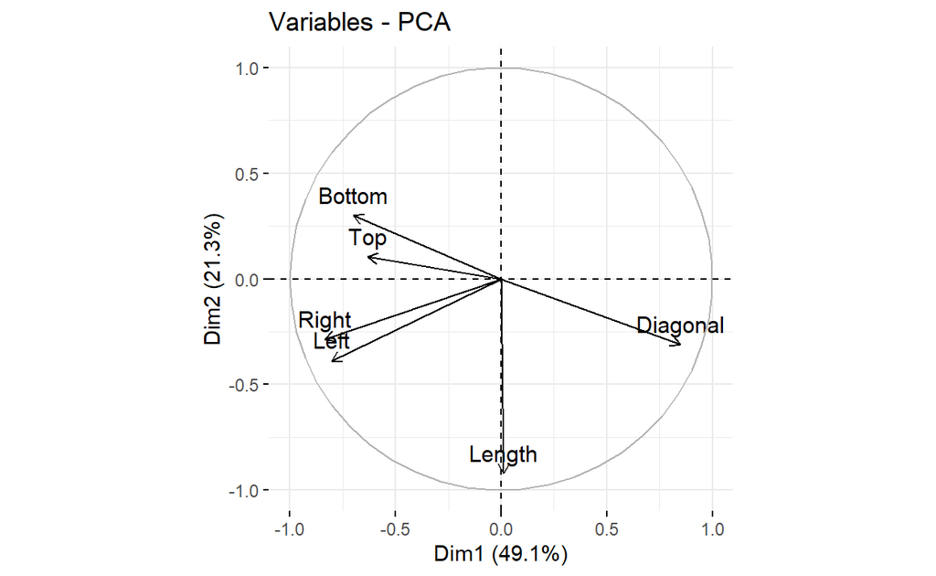

```r
# 변수 적재 그래프
fviz_pca_var(swissTib.cor.prcomp)
```

`Result!` 그래프의 x축과 y축은 각각 첫 번째 주성분과 두 번째 주성분에 대한 변수 적재값을 의미하며, 특정 주축을 기준으로 화살표의 길이가 길수록 해당 변수와 해당 주성분은 강한 상관성을 가진다.

```r
# 주성분 점수
swissTib.cor.score <- swissTib.cor.prcomp$x
swissTib.cor.score
```

```
               PC1          PC2          PC3         PC4
  [1,] -1.74302723 -1.646696046 -1.420197269 -2.74796911
  [2,]  2.26862482  0.537444608 -0.531315146 -0.65735578
  [3,]  2.27170086  0.107407538 -0.715619112 -0.34083839
  [4,]  2.27783852  0.087434897  0.604117608 -0.39182554
  [5,]  2.62553969 -0.039097788 -3.188383676  0.42401683
  [6,] -0.75650894 -3.081013588 -0.784511718 -0.59803217
  [7,]  2.51212347 -1.223914242 -0.243028293  0.92666684
  [8,]  2.70215331  1.131990218  1.185984540 -0.25489648
  [9,]  2.03311114  0.313693202  0.979796097  0.29444051
 [10,] -0.31691634 -1.302449879 -0.742024634 -0.43024244
 [11,] -0.25684271 -1.826416610  1.346535045 -0.78169056
 [12,]  2.52605080 -0.372122462  0.673006474  0.28633636
 [13,]  0.30721041 -1.558830894  0.597963961 -0.61394121
 [14,]  1.74166195  0.406674107  1.008149839 -0.42434228
```

[output cut: 387 more lines]

`Caution!` 주성분 점수는 각 case의 관측값을 주성분에 대입함으로써 얻을 수 있으며, 고차원의 원본 데이터셋 대신 차원이 축소된 데이터셋으로 유용하게 사용될 수 있다. 함수 `prcomp()`를 이용한 결과 `swissTib.cor.prcomp`에는 주성분 점수가 포함되어 있다.
`Result!` 첫 번째 주성분과 두 번째 주성분에 의해 얻어지는 $i$번째 case의 주성분 점수는 다음의 식을 이용하여 얻을 수 있다.
$$\begin{align}
\begin{cases}
y_{i1}=0.007z_{i1}-0.468z_{i2}-0.487z_{i3}-0.407z_{i4}-0.368z_{i5}+0.493z_{i6},\\
y_{i2}=-0.815z_{i1}-0.342z_{i2}-0.252z_{i3}+0.266z_{i4}+0.091z_{i5}-0.274z_{i6},
\end{cases}
\end{align}$$
여기서 $z_{ij}=(x_{ij}-\bar{x}_{j})/s_{j}$는 $i$번째 case의 $j$번째 변수 관찰값 $x_{ij}$에서 $j$번째 변수의 평균값 $\bar{x}_j$을 뺀 후 $j$번째 변수의 표준편차 값 $s_j$로 나눈 것을 의미한다.

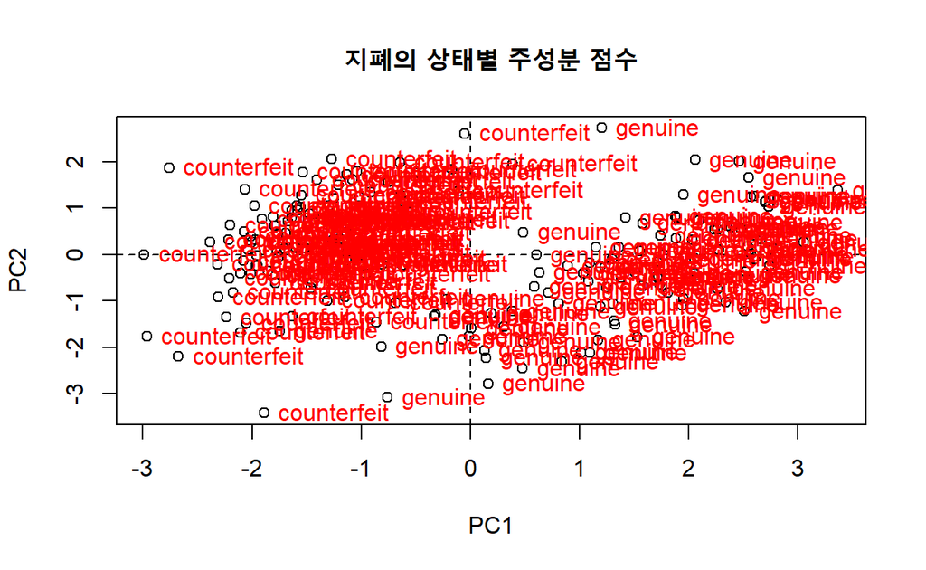

```r
# 지폐의 상태에 따른 주성분 점수 그래프 Ver.1
plot(swissTib.cor.score[,1:2],                         # 첫 번째와 두 번째 주성분 점수
     main = "지폐의 상태별 주성분 점수")
abline(v = 0, h = 0, lty = 2)
text(swissTib.cor.score[,1:2],  labels = swissTib$Status, pos = 4, col = "red")
```

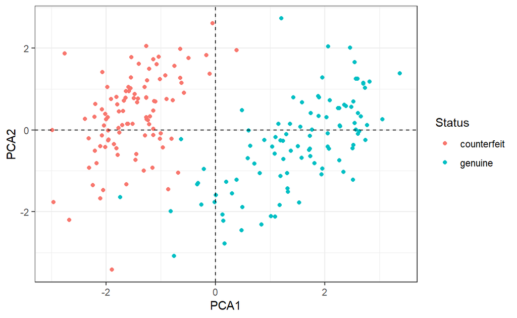

```r
# 지폐의 상태에 따른 주성분 점수 그래프 Ver.2
swissTibPca <- swissTib %>%
  mutate(PCA1 = swissTib.cor.score[, 1], PCA2 = swissTib.cor.score[, 2])
ggplot(swissTibPca, aes(PCA1, PCA2,
                        col = Status)) +               # 변수 Status의 범주에 따라 색깔을 다르게 표현
  geom_point() +
  geom_hline(yintercept=0, linetype='dashed', color='black') +
  geom_vline(xintercept=0, linetype='dashed', color='black') +
  theme_bw()
```

`Result!` 그래프의 수직선을 중심으로 오른쪽에 위치하는 점들은 첫 번째 주성분 점수가 높다는 것을 의미하고 왼쪽에 위치하는 점들은 첫 번째 주성분 점수가 낮다는 것을 의미한다. 오른쪽에 위치하는 점들은 대부분 “진품”(genuine)이므로, 전반적으로 진품인 지폐가 위조 지폐보다 첫 번째 주성분 점수가 높다고 해석할 수 있다. 마찬가지로 수평선을 중심으로 위쪽에 위치하는 점들은 두 번째 주성분 점수가 높다는 것을 의미하고 아래쪽에 위치하는 점들은 두 번째 주성분 점수가 낮다는 것을 의미한다.

```r
# 주성분 점수 예측
predict(swissTib.cor.prcomp, newdata = tail(swissTib[,-1], 2))
```

```
            PC1          PC2        PC3         PC4        PC5
[1,] -2.9867821 -0.001793364 -0.5065873 -0.88804668 -0.3230792
[2,] -0.6439339  1.986895264  0.6571704  0.02876048 -0.3019170
             PC6
[1,] -0.02754178
[2,] -0.12457045
```

`Caution!` 함수 `predict()`를 이용하여 새로운 case에 대한 주성분 점수를 예측할 수 있다. 여기서는 설명의 편의상 마지막 2개의 case를 새로운 자료로 취급하여 예측을 수행하였다.

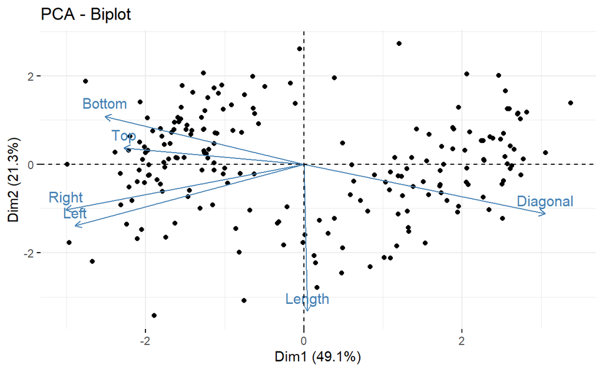

```r
# Biplot
fviz_pca_biplot(swissTib.cor.prcomp, label = "var")
```

`Caution!` 주성분 점수와 변수 적재를 하나의 그래프에 함께 표현한 것을 행렬도(Biplot)라고 한다. 위 Biplot에서는 주성분 점수를 점으로 표현하고, 변수 적재를 화살표로 표현한다. Biplot는 다음을 기준으로 해석할 수 있다.  
1. 점은 각 case(데이터셋에서 하나의 행)에 대한 주성분 점수를 나타낸다.  
2. 화살표는 변수 적재값을 의미하며, 정확한 변수 적재값은 알 수 없다.  
3. 화살표의 길이는 상관성의 정도를 표현한다. 즉, 주축을 기준으로 화살표의 길이가 길수록 변수와 해당 주성분은 강한 상관성을 가진다.  
4. 화살표와 주축이 평행에 가까울수록 해당 변수는 해당 주성분에만 큰 영향을 미친다.  
5. 화살표들 간의 각도가 작을수록 해당 변수들은 강한 양의 상관관계를 나타내며, 180도는 강한 음의 상관관계를 나타낸다. 또한, 직각은 상관성이 없음을 의미한다.  
Biplot을 통해서 군집성, 변수들의 상관구조 등을 시각적으로 파악할 수 있다.  
`Result!` Biplot의 x축과 y축은 각각 첫 번째와 두 번째 주성분 점수를 의미한다. 변수 `Right`와 `Diagonal`은 첫 번째 주축(x축, 수평 점선)을 기준으로 화살표의 길이가 길며 이는 두 변수가 첫 번째 주성분과 강한 상관성을 가진다고 할 수 있다. 또한, 변수 `Right`와 `Left`의 화살표들 간의 각도가 작기 때문에(즉, 서로 가까이 위치해있기 때문에) 강한 양의 상관관계를 가지며, 변수 `Bottom`과 `Diagonal`은 화살표들 간의 각도가 180도를 이루므로 강한 음의 상관관계를 가진다.

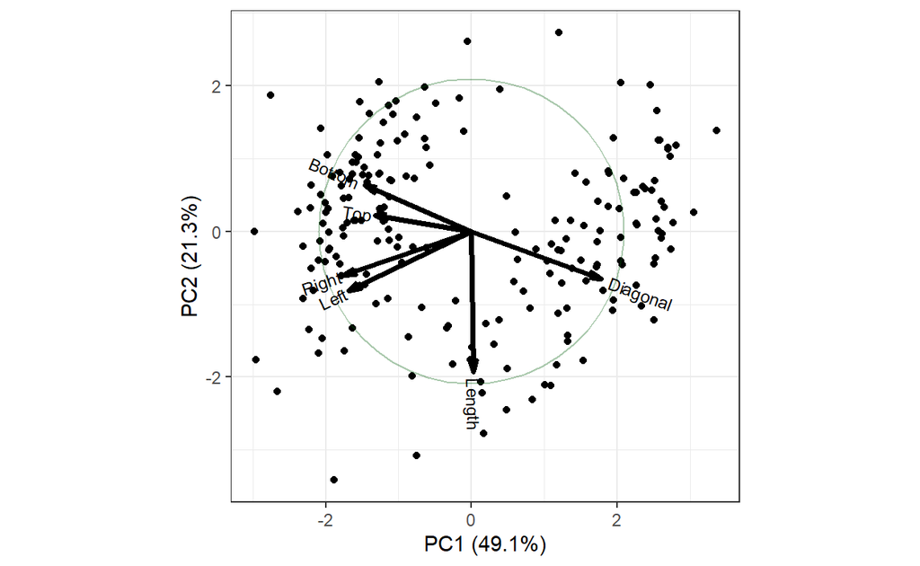

```r
# ggbiplot을 이용한 Biplot
ggbiplot(swissTib.cor.prcomp,                          # 함수 prcomp에 의한 객체
         obs.scale = 1,                                # 관찰값에 적용할 스케일
         var.scale = 1,                                # 변수에 적용할 스케일
         circle = TRUE) +
  theme_bw()
```

`Caution!` Package `"ggbiplot"`에서 제공하는 함수 `ggbiplot()`를 이용하여 Biplot을 만들 수 있으며, 함수에 대한 자세한 옵션은 [여기](https://www.rdocumentation.org/packages/ggbiplot/versions/0.55/topics/ggbiplot)를 참고한다.

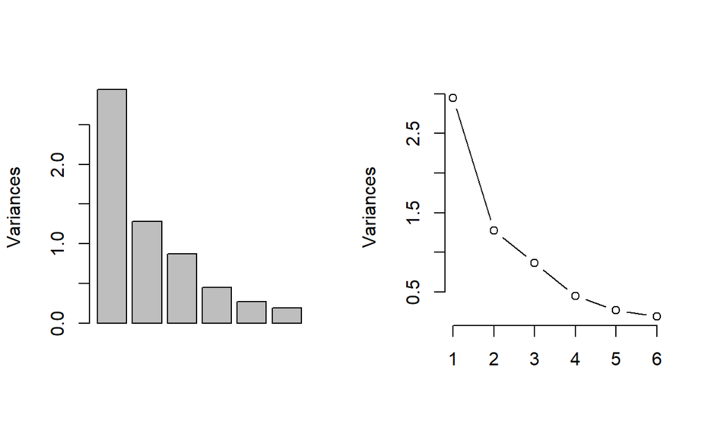

```r
# 스크리 그래프 Ver.1 (y축 : 고유값)
par(mfrow = c(1, 2))
screeplot(swissTib.cor.prcomp, type = "b", main = "")  # 막대그래프
screeplot(swissTib.cor.prcomp, type = "l", main = "")  # 선 그래프
```

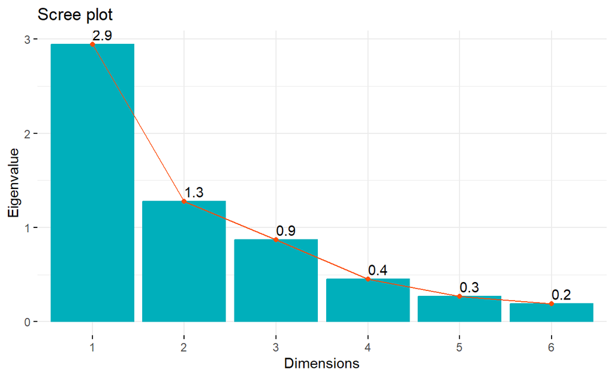

```r
# 스크리 그래프 Ver.2
fviz_screeplot(swissTib.cor.prcomp,
               addlabels = TRUE,                       # 막대 높이 표시 여부
               # geom = "line",                        # 그래프 유형(bar / line)
               choice = "eigenvalue",                  # y축 (variance / eigenvalue)
               linecolor = "#FC4E07",                  # 선 색깔
               barcolor = "#00AFBB",                   # 막대의 윤곽선 색깔
               barfill = "#00AFBB")                    # 막대의 색깔
```

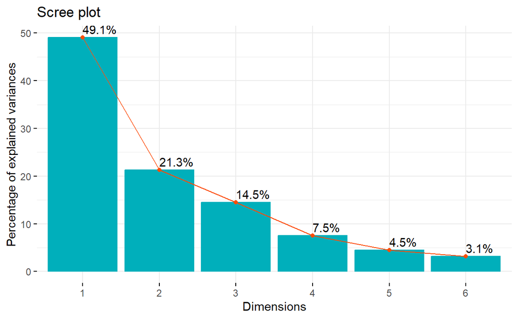

```r
fviz_screeplot(swissTib.cor.prcomp,
               addlabels = TRUE,                       # 막대 높이 표시 여부
               choice = "variance",                    # y축(variance / eigenvalue)
               linecolor = "#FC4E07",                  # 선 색깔
               barcolor = "#00AFBB",                   # 막대의 윤곽선 색깔
               barfill = "#00AFBB")                    # 막대의 색깔
```

`Result!` 스크리 그래프를 보면 첫 번째 주성분, 두 번째 주성분 그리고 세 번째 주성분의 분산(고유값)이 크며 가파른 경사를 형성한다. 그러므로, 3개의 주성분 개수를 고려할 수 있다.